# Module 8. Generalized linear mixed models

Answer key

```r
source(here::here("R", "setup.R"))
clear <- load_clear() |> arrange(id, week) |> mutate(age45 = (age - 45) / 10)
diary <- load_diary() |> arrange(id, period)
f2 <- function(x, d = 2) formatC(x, format = "f", digits = d)
```

**WarningSimulated data**

All examples use simulated data from fictional studies. Results illustrate methods; they are not empirical findings.

Complete, executed solutions to the Module 8 workbook, with model answers and marking notes.

```r
gauss_hermite <- function(n) {
  i <- seq_len(n - 1)
  J <- matrix(0, n, n); J[cbind(i, i + 1)] <- J[cbind(i + 1, i)] <- sqrt(i / 2)
  e <- eigen(J, symmetric = TRUE)
  list(x = e$values, w = sqrt(pi) * e$vectors[1, ]^2)
}
gh <- gauss_hermite(30)
marginal_p <- function(eta, sigma)
  sapply(eta, function(e) sum(gh$w / sqrt(pi) * plogis(e + sqrt(2) * sigma * gh$x)))
```

## 1 Guided exercises

### 1.1 Exercise 1. Laplace or quadrature?

```r
m_lap <- glmer(itch ~ week * arm + (1 | id), data = clear, family = binomial, nAGQ = 1)
m_agq <- glmer(itch ~ week * arm + (1 | id), data = clear, family = binomial, nAGQ = 25)
m_tmb <- glmmTMB(itch ~ week * arm + (1 | id), data = clear, family = binomial)
cmp1 <- rbind(laplace = c(fixef(m_lap), sd = unname(attr(VarCorr(m_lap)$id, "stddev"))),
              agq = c(fixef(m_agq), sd = unname(attr(VarCorr(m_agq)$id, "stddev"))),
              glmmTMB = c(fixef(m_tmb)$cond, sd = unname(attr(VarCorr(m_tmb)$cond$id, "stddev"))))
round(cmp1, 4)
```

```
#>         (Intercept)    week armActive week:armActive    sd
#> laplace      0.1376 -0.0964   -0.1172        -0.1270 1.668
#> agq          0.1331 -0.0959   -0.1128        -0.1299 1.760
#> glmmTMB      0.1375 -0.0964   -0.1172        -0.1270 1.668
```

**(c)** `glmmTMB` agrees with the Laplace fit because it uses the Laplace approximation.

*Marking notes.* Accept any `nAGQ` of 10 or more for the AGQ fit.

### 1.2 Exercise 2. Conditional interpretation and residual checks

```r
ft <- fixef_table(m_agq, exponentiate = TRUE); ft
```

```
#>             term estimate      se  lower  upper        p
#> 1    (Intercept)   1.1423 0.25346 0.6951 1.8773 0.599586
#> 2           week   0.9086 0.02925 0.8579 0.9622 0.001043
#> 3      armActive   0.8933 0.36311 0.4384 1.8200 0.755983
#> 4 week:armActive   0.8782 0.04518 0.8038 0.9595 0.004050
```

```r
fc <- fixef(m_agq); sig <- attr(VarCorr(m_agq)$id, "stddev")
c(or_week12 = exp(12 * fc["week:armActive"]), icc_latent = sig^2 / (sig^2 + pi^2 / 3))
```

```
#> or_week12.week:armActive   icc_latent.(Intercept)
#>                   0.2105                   0.4851
```

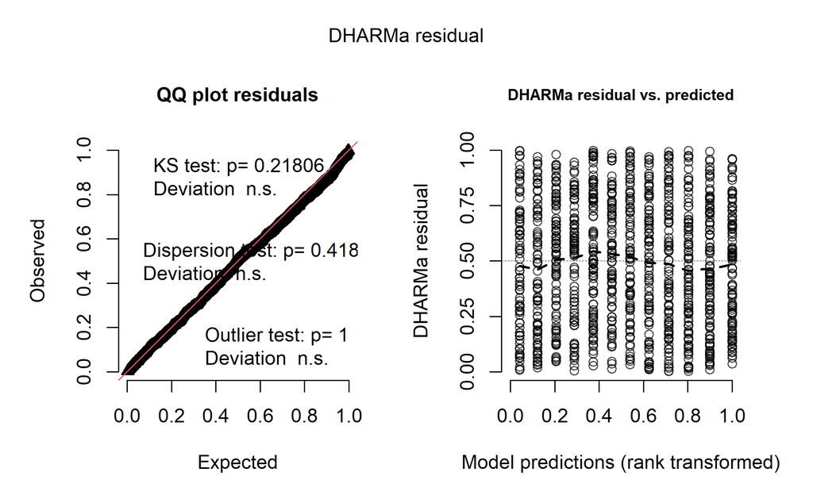

```r
res <- simulateResiduals(m_agq, n = 1000, seed = 1)
plot(res, quantreg = FALSE)
```

```r
testDispersion(res, plot = FALSE)
```

```
#>
#>  DHARMa nonparametric dispersion test via sd of residuals fitted vs.
#>  simulated
#>
#> data:  simulationOutput
#> dispersion = 1, p-value = 0.4
#> alternative hypothesis: two.sided
```

**(b)** For a given participant on placebo, the odds of moderate or severe itch are multiplied by 0.909 each week. For a given participant on active treatment, they are multiplied each week by a further 0.878 (95% CI 0.804 to 0.960).

**(c)** The conditional odds ratio at week 12 is 0.21: a participant on active treatment has odds of itch about 79% lower than a participant on placebo with the same random intercept and baseline odds. The latent ICC is 0.49.

**(d)** The QQ plot follows the diagonal, the residuals show no pattern against the predictions, and the dispersion test is not significant (p = 0.418): no evidence of misfit.

*Marking notes.* The phrase “for a given participant” (or equivalent) is required for full marks in (b).

### 1.3 Exercise 3. Why do GLMM and GEE coefficients differ?

```r
gee <- geeglm(itch ~ week * arm, id = factor(id), waves = visit, data = clear,
              family = binomial, corstr = "exchangeable")
atten <- 1 / sqrt(1 + 0.346 * sig^2)
grid <- expand.grid(week = c(0, 2, 4, 6, 8, 12),
                    arm = factor(c("Placebo", "Active"), levels = c("Placebo", "Active")))
X <- model.matrix(~ week * arm, grid)
grid$p <- marginal_p(X %*% fc, sig)
exact <- coef(suppressWarnings(glm(p ~ week * arm, family = binomial, data = grid)))
t3 <- cbind(glmm = fc, approx_marginal = fc * atten, exact_marginal = exact, gee = coef(gee))
round(t3, 4)
```

```
#>                   glmm approx_marginal exact_marginal     gee
#> (Intercept)     0.1331          0.0924         0.0875  0.0849
#> week           -0.0959         -0.0666        -0.0628 -0.0634
#> armActive      -0.1128         -0.0784        -0.0637 -0.0634
#> week:armActive -0.1299         -0.0902        -0.0895 -0.0844
```

```r
true_marg <- c(-0.06, -0.16) / sqrt(1 + 0.346 * 2^2); true_marg
```

```
#> [1] -0.03886 -0.10363
```

**(b, c)** The attenuation factor is 0.695. The approximate marginal interaction is -0.0902, the exact one -0.0895, and GEE estimates -0.0844, against a conditional -0.1299.

**(d)** GEE estimates should be compared with the true *marginal* values, about -0.039 (week) and -0.104 (week:armActive) by the approximation. Comparing them with −0.06 and −0.16 would wrongly suggest that GEE is biased towards zero.

**(e)** Model answer: “The mixed-model odds ratio compares the same patient on and off treatment; because patients differ a lot in their underlying tendency to itch, an individual’s odds change more steeply than the overall proportion in a group of patients. The GEE (or the averaged mixed-model) result describes the proportion of patients with itch, so it answers your question: at week 12, about 34% on placebo and 14% on active treatment.”

*Marking notes.* Common error: concluding that one of the two analyses is wrong.

### 1.4 Exercise 4. Predicted probabilities with uncertainty

```r
emmeans(m_agq, ~ arm | week, at = list(week = c(0, 12)), type = "response")
```

```
#> week =  0:
#>  arm       prob     SE  df asymp.LCL asymp.UCL
#>  Placebo 0.5332 0.0631 Inf    0.4101     0.652
#>  Active  0.5051 0.0650 Inf    0.3801     0.629
#>
#> week = 12:
#>  arm       prob     SE  df asymp.LCL asymp.UCL
#>  Placebo 0.2655 0.0596 Inf    0.1657     0.397
#>  Active  0.0636 0.0215 Inf    0.0324     0.121
#>
#> Confidence level used: 0.95
#> Intervals are back-transformed from the logit scale
```

```r
V_joint <- 2 * solve(m_agq@optinfo$derivs$Hessian)
set.seed(1)
draws <- MASS::mvrnorm(4000, mu = c(getME(m_agq, "theta"), fc), Sigma = V_joint)
pg <- expand.grid(arm = factor(c("Placebo", "Active"), levels = c("Placebo", "Active")),
                  week = c(0, 12))
Xp <- model.matrix(~ week * arm, pg)
md <- apply(draws, 1, function(d) marginal_p(Xp %*% d[-1], abs(d[1])))
pg$marginal <- marginal_p(Xp %*% fc, sig)
pg$lower <- apply(md, 1, quantile, 0.025)
pg$upper <- apply(md, 1, quantile, 0.975)
pg
```

```
#>       arm week marginal   lower  upper
#> 1 Placebo    0   0.5217 0.44110 0.6037
#> 2  Active    0   0.5033 0.41944 0.5861
#> 3 Placebo   12   0.3391 0.25312 0.4297
#> 4  Active   12   0.1387 0.08736 0.2058
```

```r
rd <- c(pg$marginal[4] - pg$marginal[3], quantile(md[4, ] - md[3, ], c(0.025, 0.975)))
rr <- c(pg$marginal[4] / pg$marginal[3], quantile(md[4, ] / md[3, ], c(0.025, 0.975)))
rbind(risk_difference = rd, risk_ratio = rr) |> round(3)
```

```
#>                          2.5%  97.5%
#> risk_difference -0.200 -0.306 -0.096
#> risk_ratio       0.409  0.244  0.654
```

**(a)** These are probabilities for a participant with random intercept 0 (a median participant), with delta-method intervals; they are not population proportions.

**(c)** Marginal risk difference at week 12: -0.200 (-0.306 to -0.096); risk ratio 0.41 (0.24 to 0.65).

**(d)** Averaging the S-shaped inverse logit over participants with very low and very high propensities mixes probabilities near 0 and near 1, pulling the average towards 0.5.

*Marking notes.* Draw-based intervals vary slightly with the seed. Accept a parametric bootstrap (`bootMer`) as an alternative.

### 1.5 Exercise 5. Poisson or negative binomial?

```r
m_pois <- glmmTMB(migraine_days ~ post * arm + offset(log(days)) + (1 | id),
                  data = diary, family = poisson)
m_nb <- glmmTMB(migraine_days ~ post * arm + offset(log(days)) + (1 | id),
                data = diary, family = nbinom2)
pr <- sum(residuals(m_pois, type = "pearson")^2) / df.residual(m_pois); pr
```

```
#> [1] 1.579
```

```r
r_pois <- simulateResiduals(m_pois, n = 1000, seed = 1)
r_nb <- simulateResiduals(m_nb, n = 1000, seed = 1)
testDispersion(r_pois, plot = FALSE); testDispersion(r_nb, plot = FALSE)
```

```
#>
#>  DHARMa nonparametric dispersion test via sd of residuals fitted vs.
#>  simulated
#>
#> data:  simulationOutput
#> dispersion = 1.5, p-value <2e-16
#> alternative hypothesis: two.sided
```

```
#>
#>  DHARMa nonparametric dispersion test via sd of residuals fitted vs.
#>  simulated
#>
#> data:  simulationOutput
#> dispersion = 1.1, p-value = 0.09
#> alternative hypothesis: two.sided
```

```r
k <- "post:armActive"
rbind(poisson = c(est = fixef(m_pois)$cond[k], se = sqrt(vcov(m_pois)$cond[k, k])),
      negbin = c(est = fixef(m_nb)$cond[k], se = sqrt(vcov(m_nb)$cond[k, k])))
```

```
#>         est.post:armActive      se
#> poisson            -0.2272 0.08011
#> negbin             -0.1966 0.11958
```

**(b, c)** The Pearson ratio of the Poisson model is 1.58 and the DHARMa test signals overdispersion; the NB model shows none. The Poisson SE of the treatment effect (0.080) is much smaller than the NB SE (0.120) because the Poisson model ignores the extra variation. Report the NB model.

*Marking notes.* Penalise reporting the Poisson model’s p-value as evidence of an effect.

### 1.6 Exercise 6. Zero inflation, rate ratios and expected counts

```r
testZeroInflation(r_pois, plot = FALSE); testZeroInflation(r_nb, plot = FALSE)
```

```
#>
#>  DHARMa zero-inflation test via comparison to expected zeros with
#>  simulation under H0 = fitted model
#>
#> data:  simulationOutput
#> ratioObsSim = 1.6, p-value <2e-16
#> alternative hypothesis: two.sided
```

```
#>
#>  DHARMa zero-inflation test via comparison to expected zeros with
#>  simulation under H0 = fitted model
#>
#> data:  simulationOutput
#> ratioObsSim = 1.1, p-value = 0.6
#> alternative hypothesis: two.sided
```

```r
m_zinb <- glmmTMB(migraine_days ~ post * arm + offset(log(days)) + (1 | id),
                  ziformula = ~ 1, data = diary, family = nbinom2)
AIC(m_pois, m_nb, m_zinb)
```

```
#>        df  AIC
#> m_pois  5 5065
#> m_nb    6 4827
#> m_zinb  7 4829
```

```r
t6 <- fixef_table(m_nb, exponentiate = TRUE); t6
```

```
#>             term estimate      se  lower  upper         p
#> 1    (Intercept)   0.1804 0.09559 0.1496 0.2176 8.859e-72
#> 2           post   0.8344 0.08321 0.7088 0.9822 2.954e-02
#> 3      armActive   0.8922 0.13615 0.6832 1.1650 4.020e-01
#> 4 post:armActive   0.8215 0.11958 0.6499 1.0385 1.001e-01
```

```r
s_nb <- attr(VarCorr(m_nb)$cond$id, "stddev")
e_c <- emmeans(m_nb, ~ arm | post, offset = log(28), type = "response"); e_c
```

```
#> post = 0:
#>  arm     response    SE  df asymp.LCL asymp.UCL
#>  Placebo     5.05 0.483 Inf      4.19      6.09
#>  Active      4.51 0.438 Inf      3.73      5.45
#>
#> post = 1:
#>  arm     response    SE  df asymp.LCL asymp.UCL
#>  Placebo     4.21 0.288 Inf      3.69      4.82
#>  Active      3.09 0.216 Inf      2.69      3.54
#>
#> Confidence level used: 0.95
#> Intervals are back-transformed from the log scale
```

```r
e_m <- emmeans(m_nb, ~ arm | post, offset = log(28), type = "response",
               bias.adjust = TRUE, sigma = s_nb); e_m
```

```
#> post = 0:
#>  arm     response    SE  df asymp.LCL asymp.UCL
#>  Placebo     5.73 0.548 Inf      4.75      6.91
#>  Active      5.11 0.497 Inf      4.23      6.19
#>
#> post = 1:
#>  arm     response    SE  df asymp.LCL asymp.UCL
#>  Placebo     4.78 0.327 Inf      4.18      5.47
#>  Active      3.50 0.245 Inf      3.06      4.02
#>
#> Confidence level used: 0.95
#> Intervals are back-transformed from the log scale
#> Bias adjustment applied based on sigma = 0.51924
```

**(a)** The Poisson model appears zero-inflated, the NB model does not, and the ZINB model has a higher AIC than the NB model. The excess zeros of the Poisson model are a consequence of overdispersion; there is no evidence (and no substantive reason) for a separate zero process.

**(b)** Ratio of rate ratios 0.82 (0.65 to 1.04).

**(c)** During treatment, for $b_{0i} = 0$: 4.2 (placebo) and 3.1 (active) migraine days per 28 days; averaged over participants: 4.8 and 3.5.

**(d)** With a log link, $E(Y) = \exp(\mathbf{x}^\top\boldsymbol\beta)\,E\{\exp(b_{0i})\}$: averaging over the random intercept multiplies every mean by the same constant $\exp(\tau_0^2/2)$, so ratios are unchanged. With a logit link the averaging changes the shape of the curve and the odds ratios shrink towards 1.

### 1.7 Exercise 7. Categorical time in the CLEAR GLMM

```r
m7 <- glmer(itch ~ week_f * arm + (1 | id), data = clear, family = binomial, nAGQ = 25,
            control = glmerControl(optimizer = "bobyqa"))
f7 <- fixef(m7); s7 <- attr(VarCorr(m7)$id, "stddev")
or12 <- confint(contrast(emmeans(m7, ~ arm | week_f, at = list(week_f = "12")),
                         "revpairwise"), type = "response")
or12
```

```
#> week_f = 12:
#>  contrast         odds.ratio     SE  df asymp.LCL asymp.UCL
#>  Active / Placebo      0.164 0.0932 Inf    0.0538       0.5
#>
#> Confidence level used: 0.95
#> Intervals are back-transformed from the log odds ratio scale
```

```r
V7 <- 2 * solve(m7@optinfo$derivs$Hessian)
set.seed(7)
d7 <- MASS::mvrnorm(4000, c(getME(m7, "theta"), f7), V7)
nd <- data.frame(week_f = factor("12", levels = levels(clear$week_f)),
                 arm = factor(c("Placebo", "Active"), levels = c("Placebo", "Active")))
X7 <- model.matrix(~ week_f * arm, nd)
md7 <- apply(d7, 1, function(d) marginal_p(X7 %*% d[-1], abs(d[1])))
p7 <- marginal_p(X7 %*% f7, s7)
rd7 <- c(p7[2] - p7[1], quantile(md7[2, ] - md7[1, ], c(0.025, 0.975)))
round(rd7, 3)
```

```
#>          2.5%  97.5%
#> -0.217 -0.345 -0.082
```

The conditional odds ratio at week 12 is 0.16 (0.05 to 0.50) and the population-averaged risk difference -0.217 (-0.345 to -0.082), compared with -0.200 (-0.306 to -0.096) from the linear-in-week model. The categorical model makes no assumption about the shape of the trajectory and its interval is wider.

With the default optimiser this model reports a convergence warning (a large gradient); switching to `glmerControl(optimizer = "bobyqa")`, as here, converges cleanly. Module 11 discusses convergence warnings in detail.

*Marking notes.* Note that the conditional odds ratio includes the baseline difference term; accept either a comparison at week 12 or a difference-in-change formulation if clearly described.

### 1.8 Exercise 8. A random slope for week?

```r
m8_ri <- glmer(itch ~ week * arm + (1 | id), data = clear, family = binomial)
m8_rs <- glmer(itch ~ week * arm + (1 + week | id), data = clear, family = binomial)
```

```
#> boundary (singular) fit: see help('isSingular')
```

```r
VarCorr(m8_rs)
```

```
#>  Groups Name        Std.Dev. Corr
#>  id     (Intercept) 1.3567
#>         week        0.0735   1.00
```

```r
lr8 <- lr_test(m8_ri, m8_rs); lr8
```

```
#>   logLik_0 logLik_1 chisq df      p
#> 1     -591   -589.4 3.314  2 0.1907
```

```r
p_mix <- 0.5 * pchisq(lr8$chisq, 1, lower.tail = FALSE) +
  0.5 * pchisq(lr8$chisq, 2, lower.tail = FALSE)
p_mix
```

```
#> [1] 0.1297
```

Read any convergence or singular-fit message printed above: a random-slope variance close to zero or a correlation at ±1 indicates that the data contain little information about slope variation. The likelihood-ratio statistic is 3.31; with the boundary-corrected 50:50 mixture of $\chi^2_1$ and $\chi^2_2$ the p-value is p = 0.130. There is no evidence that a random slope is needed, consistent with the generating model, which has a random intercept only. With a random slope the variance of $b_{0i} + b_{1i}t$ changes over time, so the attenuation factor differs by week and no single factor converts all coefficients.

*Marking notes.* Credit use of the boundary-corrected reference distribution (Module 5) and recognition that AGQ is not available with two random effects in `glmer`.

### 1.9 Exercise 9. Period-specific rate ratios in DIARY

```r
m9 <- glmmTMB(migraine_days ~ period_f * arm + offset(log(days)) + (1 | id),
              data = diary, family = nbinom2)
e9 <- emmeans(m9, ~ period_f * arm)
rr9 <- confint(contrast(e9, interaction = c("trt.vs.ctrl1", "revpairwise")),
               type = "response")
rr9
```

```
#>  period_f_trt.vs.ctrl1 arm_revpairwise  ratio    SE  df asymp.LCL asymp.UCL
#>  1 / 0                 Active / Placebo 0.876 0.138 Inf     0.643     1.194
#>  2 / 0                 Active / Placebo 0.643 0.102 Inf     0.471     0.878
#>  3 / 0                 Active / Placebo 0.881 0.142 Inf     0.642     1.209
#>  4 / 0                 Active / Placebo 0.860 0.142 Inf     0.622     1.187
#>  5 / 0                 Active / Placebo 0.983 0.162 Inf     0.712     1.357
#>  6 / 0                 Active / Placebo 0.748 0.124 Inf     0.540     1.036
#>
#> Confidence level used: 0.95
#> Intervals are back-transformed from the log scale
```

The period-specific ratios of rate ratios range from 0.64 to 0.98, with wide, overlapping intervals and no trend, so a single post-baseline effect is a reasonable and more precise summary (the generating model has a constant effect).

### 1.10 Exercise 10. Attenuation by simulation

```r
sim_att <- function(sd_b, n = 2000, beta = -1) {
  d <- expand.grid(visit = 1:6, id = seq_len(n))
  d$trt <- as.integer(d$id > n / 2)
  b <- rnorm(n, 0, sd_b)
  d$y <- rbinom(nrow(d), 1, plogis(beta * d$trt + b[d$id]))
  coef(geeglm(y ~ trt, id = id, data = d, family = binomial,
              corstr = "independence"))["trt"]
}
set.seed(10)
att <- data.frame(sd_b = c(0, 1, 2, 3))
att$gee <- sapply(att$sd_b, sim_att)
att$approx <- -1 / sqrt(1 + 0.346 * att$sd_b^2)
# exact marginal log-odds ratio by numerical integration
att$exact <- sapply(att$sd_b, function(s) qlogis(marginal_p(-1, s)) - qlogis(marginal_p(0, s)))
att
```

```
#>   sd_b     gee  approx   exact
#> 1    0 -0.9869 -1.0000 -1.0000
#> 2    1 -0.7940 -0.8619 -0.8318
#> 3    2 -0.6354 -0.6477 -0.6091
#> 4    3 -0.5869 -0.4930 -0.4610
```

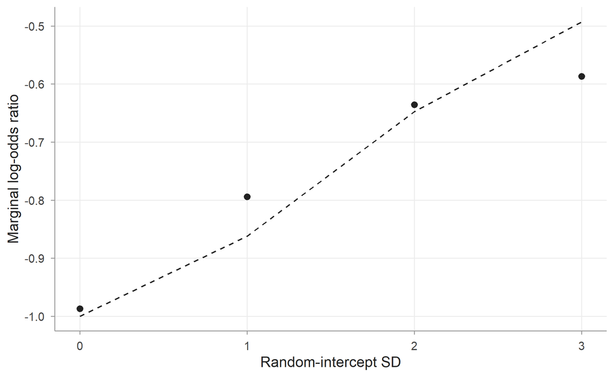

```r
ggplot(att, aes(sd_b)) +
  geom_line(aes(y = approx), linetype = 2) +
  geom_point(aes(y = gee), size = 2) +
  labs(x = "Random-intercept SD", y = "Marginal log-odds ratio")
```

The marginal log-odds ratio estimated by GEE shrinks towards zero as the random-intercept SD grows, following the approximation (dashed line); at $\tau_0 = 0$ it is close to the conditional value −1. The exact values from numerical integration (-1.00, -0.83, -0.61, -0.46) and the approximation (-1.00, -0.86, -0.65, -0.49) agree closely. The GEE estimates (-0.99, -0.79, -0.64, -0.59) come from one simulated dataset per SD, so they scatter around the exact values because of sampling error, which with 2,000 participants is of the order of 0.05 to 0.1 on the log-odds scale.

*Marking notes.* Small departures from the line reflect sampling error and, at large SDs, the limits of the approximation.